# MB4-MB26v1.4 UMAPS and propeller for fig 2

Michelle Biederman

1/23/25

# Purpose

I need TIFFs of the plots for my figures. Plotting in console to save.

Adusted window so divide was under D of Debug in the menu above.

# Load libpaths

```r
.libPaths("/apps/R/4.3.2/seurat/5.1.0")
```

```r
#if (!require("BiocManager", quietly = TRUE))
    install.packages("BiocManager")
```

```
Error in install.packages : Updating loaded packages
```

```r
#BiocManager::install("svglite")
```

# Load the libraries

```r
library(speckle, lib="/home/biederman/R/x86_64-pc-linux-gnu-library/4.3/")
install.packages("BiocManager")
n
```

```
Error in install.packages : unable to install packages
```

```r
library(Seurat)
library(CellBench, lib="/home/biederman/R/x86_64-pc-linux-gnu-library/4.3/")
library(limma, lib="/home/biederman/R/x86_64-pc-linux-gnu-library/4.3/")
library(ggplot2)
library(scater, lib="/apps/R/4.3.2/osca/")
library(patchwork)
library(edgeR, lib="/apps/R/4.3.2/osca/")
library(statmod, lib="/apps/R/4.3.2/osca/")
library(dplyr)
library(ggplot2)
library(RColorBrewer)
library(viridisLite)
library(cowplot)
library(tidyr)
library(ape, lib="/apps/R/4.3.2/DESeq2")
library(paletteer, lib="/home/biederman/R/x86_64-pc-linux-gnu-library/4.3/")
library(prismatic, lib="/home/biederman/R/x86_64-pc-linux-gnu-library/4.3/")
library(svglite, lib="/home/biederman/R/x86_64-pc-linux-gnu-library/4.3/")
```

# Load data

```r
MB.combined <- readRDS("/mnt/sequence/home/biederman/230602_v1/filtered/250113_atlas_v1_4.rds")
MB.combined
```

```
An object of class Seurat
29597 features across 182394 samples within 2 assays
Active assay: integrated (2000 features, 2000 variable features)
 2 layers present: data, scale.data
 1 other assay present: RNA
 2 dimensional reductions calculated: pca, umap
```

# Check metadata

```r
head(MB.combined@meta.data)
```

|  | orig.ident | nCount_RNA | nFeature_RNA | sample_name | condition | percent.mt | nFeature_RNA_M3MAD | nCount_RNA_M3MAD | integrated_snn_res.20 | seurat_clusters | system | tissue | cell_type_general | cell_type_cluster | short_cell_type | high_mito | high_ribo | possible_doublets |
| --- | --- | --- | --- | --- | --- | --- | --- | --- | --- | --- | --- | --- | --- | --- | --- | --- | --- | --- |
| AAACCCAAGCACCGTC-1_1 | MB6 | 1297 | 685 | t0_sample1_UF | t0_UF | 4.394757 | 2461.373 | 4624.147 | 107 | 107 | connective tissue | brain | Meninges precursor | Meninges_precursor_107 | MeningePre | no | no | no |
| AAACCCAAGCGGTAGT-1_1 | MB6 | 1604 | 1068 | t0_sample1_UF | t0_UF | 2.244389 | 2461.373 | 4624.147 | 79 | 79 | nervous system | ear/otic | Hair cell | Hair_cell_79 | HairCell | no | no | no |
| AAACCCAAGCTACAAA-1_1 | MB6 | 1165 | 615 | t0_sample1_UF | t0_UF | 3.261803 | 2461.373 | 4624.147 | 248 | 248 | connective tissue | fin | Pectoral fin mesenchyme probably chondrogenic | Pectoral_fin_mesenchyme_probably_chondrogenic_248 | PecFinMCho | no | no | no |
| AAACCCAAGGCATTTC-1_1 | MB6 | 825 | 248 | t0_sample1_UF | t0_UF | 10.666667 | 2461.373 | 4624.147 | 20 | 20 | skeletomuscular | muscle | Skeletal fast muscle | Skeletal_fast_muscle_20 | SkelFastMu | no | no | no |
| AAACCCAAGGCCATAG-1_1 | MB6 | 3274 | 1376 | t0_sample1_UF | t0_UF | 3.573610 | 2461.373 | 4624.147 | 76 | 76 | nervous system | eye | Retinal pigmented epithelium | Retinal_pigmented_epithelium_76 | RetPigEpit | no | no | no |
| AAACCCAAGGGACCAT-1_1 | MB6 | 526 | 319 | t0_sample1_UF | t0_UF | 18.821293 | 2461.373 | 4624.147 | 70 | 70 | digestive | intestine/liver/pancreas | Gut progenitor maybe HIGH MITO | Gut_progenitor_maybe_HIGH_MITO_70 | GutProgeHM | yes | no | no |

# Add short_cell_type_cluster to metadata

```r
MB.combined@meta.data <- unite(MB.combined@meta.data, short_cell_type_cluster, short_cell_type, seurat_clusters, sep = "_", remove = FALSE)
head(MB.combined@meta.data)
```

|  | orig.ident | nCount_RNA | nFeature_RNA | sample_name | condition | percent.mt | nFeature_RNA_M3MAD | nCount_RNA_M3MAD | integrated_snn_res.20 | short_cell_type_cluster | seurat_clusters | system | tissue | cell_type_general | cell_type_cluster | short_cell_type | high_mito | high_ribo | possible_doublets |
| --- | --- | --- | --- | --- | --- | --- | --- | --- | --- | --- | --- | --- | --- | --- | --- | --- | --- | --- | --- |
| AAACCCAAGCACCGTC-1_1 | MB6 | 1297 | 685 | t0_sample1_UF | t0_UF | 4.394757 | 2461.373 | 4624.147 | 107 | MeningePre_107 | 107 | connective tissue | brain | Meninges precursor | Meninges_precursor_107 | MeningePre | no | no | no |
| AAACCCAAGCGGTAGT-1_1 | MB6 | 1604 | 1068 | t0_sample1_UF | t0_UF | 2.244389 | 2461.373 | 4624.147 | 79 | HairCell_79 | 79 | nervous system | ear/otic | Hair cell | Hair_cell_79 | HairCell | no | no | no |
| AAACCCAAGCTACAAA-1_1 | MB6 | 1165 | 615 | t0_sample1_UF | t0_UF | 3.261803 | 2461.373 | 4624.147 | 248 | PecFinMCho_248 | 248 | connective tissue | fin | Pectoral fin mesenchyme probably chondrogenic | Pectoral_fin_mesenchyme_probably_chondrogenic_248 | PecFinMCho | no | no | no |
| AAACCCAAGGCATTTC-1_1 | MB6 | 825 | 248 | t0_sample1_UF | t0_UF | 10.666667 | 2461.373 | 4624.147 | 20 | SkelFastMu_20 | 20 | skeletomuscular | muscle | Skeletal fast muscle | Skeletal_fast_muscle_20 | SkelFastMu | no | no | no |
| AAACCCAAGGCCATAG-1_1 | MB6 | 3274 | 1376 | t0_sample1_UF | t0_UF | 3.573610 | 2461.373 | 4624.147 | 76 | RetPigEpit_76 | 76 | nervous system | eye | Retinal pigmented epithelium | Retinal_pigmented_epithelium_76 | RetPigEpit | no | no | no |
| AAACCCAAGGGACCAT-1_1 | MB6 | 526 | 319 | t0_sample1_UF | t0_UF | 18.821293 | 2461.373 | 4624.147 | 70 | GutProgeHM_70 | 70 | digestive | intestine/liver/pancreas | Gut progenitor maybe HIGH MITO | Gut_progenitor_maybe_HIGH_MITO_70 | GutProgeHM | yes | no | no |

# Add metadata columns for propeller

```r
MB.combined$cluster <- MB.combined$short_cell_type_cluster
MB.combined$sample <- MB.combined$sample_name
MB.combined$group <- MB.combined$condition
```

# check new metadata

```r
head(MB.combined@meta.data)
```

|  | orig.ident | nCount_RNA | nFeature_RNA | sample_name | condition | percent.mt | nFeature_RNA_M3MAD | nCount_RNA_M3MAD | integrated_snn_res.20 | short_cell_type_cluster | seurat_clusters | system | tissue | cell_type_general | cell_type_cluster | short_cell_type | high_mito | high_ribo | possible_doublets | cluster | sample | group |
| --- | --- | --- | --- | --- | --- | --- | --- | --- | --- | --- | --- | --- | --- | --- | --- | --- | --- | --- | --- | --- | --- | --- |
| AAACCCAAGCACCGTC-1_1 | MB6 | 1297 | 685 | t0_sample1_UF | t0_UF | 4.394757 | 2461.373 | 4624.147 | 107 | MeningePre_107 | 107 | connective tissue | brain | Meninges precursor | Meninges_precursor_107 | MeningePre | no | no | no | MeningePre_107 | t0_sample1_UF | t0_UF |
| AAACCCAAGCGGTAGT-1_1 | MB6 | 1604 | 1068 | t0_sample1_UF | t0_UF | 2.244389 | 2461.373 | 4624.147 | 79 | HairCell_79 | 79 | nervous system | ear/otic | Hair cell | Hair_cell_79 | HairCell | no | no | no | HairCell_79 | t0_sample1_UF | t0_UF |
| AAACCCAAGCTACAAA-1_1 | MB6 | 1165 | 615 | t0_sample1_UF | t0_UF | 3.261803 | 2461.373 | 4624.147 | 248 | PecFinMCho_248 | 248 | connective tissue | fin | Pectoral fin mesenchyme probably chondrogenic | Pectoral_fin_mesenchyme_probably_chondrogenic_248 | PecFinMCho | no | no | no | PecFinMCho_248 | t0_sample1_UF | t0_UF |
| AAACCCAAGGCATTTC-1_1 | MB6 | 825 | 248 | t0_sample1_UF | t0_UF | 10.666667 | 2461.373 | 4624.147 | 20 | SkelFastMu_20 | 20 | skeletomuscular | muscle | Skeletal fast muscle | Skeletal_fast_muscle_20 | SkelFastMu | no | no | no | SkelFastMu_20 | t0_sample1_UF | t0_UF |
| AAACCCAAGGCCATAG-1_1 | MB6 | 3274 | 1376 | t0_sample1_UF | t0_UF | 3.573610 | 2461.373 | 4624.147 | 76 | RetPigEpit_76 | 76 | nervous system | eye | Retinal pigmented epithelium | Retinal_pigmented_epithelium_76 | RetPigEpit | no | no | no | RetPigEpit_76 | t0_sample1_UF | t0_UF |
| AAACCCAAGGGACCAT-1_1 | MB6 | 526 | 319 | t0_sample1_UF | t0_UF | 18.821293 | 2461.373 | 4624.147 | 70 | GutProgeHM_70 | 70 | digestive | intestine/liver/pancreas | Gut progenitor maybe HIGH MITO | Gut_progenitor_maybe_HIGH_MITO_70 | GutProgeHM | yes | no | no | GutProgeHM_70 | t0_sample1_UF | t0_UF |

# Change Ident to cell_type_cluster

```r
Idents(MB.combined) <- "short_cell_type_cluster"
```

# Perform logit transformation

The default of propeller is to perform the logit transformation:

```r
MB.prop.logit <- propeller(MB.combined)
```

```
extracting sample information from Seurat object
Performing logit transformation of proportions
group variable has > 2 levels, ANOVA will be performed
```

```r
MB.prop.logit
```

|  | BaselineProp | PropMean.t0_UF | PropMean.t1_15HF | PropMean.t2_30HF | PropMean.t3_60HF | PropMean.t4_120HF | PropMean.t5_240HF | Fstatistic | P.Value | FDR |
| --- | --- | --- | --- | --- | --- | --- | --- | --- | --- | --- |
| EnteroAnte_195 | 0.0016722041 | 0.0001658854 | 1.284245e-03 | 9.205717e-04 | 3.296309e-03 | 5.856971e-03 | 1.810529e-04 | 7.34655036 | 0.001313470 | 0.2822003 |
| FastMuscle_122 | 0.0033444083 | 0.0060518150 | 1.541851e-03 | 5.313038e-03 | 1.474378e-03 | 2.289023e-04 | 2.667505e-03 | 6.46338319 | 0.002401251 | 0.2822003 |
| VascularHR_66 | 0.0053181574 | 0.0062049675 | 6.178715e-03 | 8.607427e-03 | 2.925781e-03 | 9.733221e-04 | 4.775549e-03 | 6.03653800 | 0.003123988 | 0.2822003 |
| VasSmooMus_182 | 0.0018257180 | 0.0021395512 | 3.236320e-03 | 1.817638e-03 | 8.772765e-04 | 2.519874e-04 | 1.044945e-03 | 4.82281363 | 0.008267574 | 0.4011232 |
| Hepatocyte_189 | 0.0017434784 | 0.0014266369 | 2.936716e-03 | 9.872205e-04 | 6.979352e-04 | 3.481654e-03 | 9.475022e-04 | 4.62143913 | 0.009791496 | 0.4011232 |
| NucErythro_109 | 0.0036130574 | 0.0017947511 | 9.910424e-03 | 2.410963e-03 | 3.144889e-03 | 6.241973e-04 | 1.864870e-03 | 4.63848085 | 0.009974538 | 0.4011232 |
| IntSecProg_229 | 0.0011568363 | 0.0013602019 | 2.276119e-03 | 8.418959e-04 | 4.618651e-04 | 5.895697e-04 | 1.225998e-03 | 4.48742083 | 0.011010012 | 0.4011232 |
| HorizRetIn_221 | 0.0012719717 | 0.0010684035 | 7.331762e-04 | 1.056062e-03 | 8.799557e-04 | 4.018657e-03 | 4.543614e-04 | 4.40523344 | 0.011841275 | 0.4011232 |
| SkFaMuCeCr_244 | 0.0007566038 | 0.0010272679 | 2.184019e-04 | 9.473345e-04 | 4.886969e-04 | 2.042183e-04 | 1.728648e-03 | 4.11354140 | 0.015414923 | 0.4641605 |
| CephCraMus_184 | 0.0017928221 | 0.0021701817 | 9.711223e-04 | 2.696679e-03 | 1.865755e-03 | 4.199791e-04 | 2.406300e-03 | 3.90908876 | 0.018641837 | 0.5051938 |

[output cut: 261 more lines]

```r
clusters <- rownames(MB.prop.logit)
MB.prop.logit <- cbind(clusters, MB.prop.logit)
MB.prop.logit
```

|  | clusters | BaselineProp | PropMean.t0_UF | PropMean.t1_15HF | PropMean.t2_30HF | PropMean.t3_60HF | PropMean.t4_120HF | PropMean.t5_240HF | Fstatistic | P.Value | FDR |
| --- | --- | --- | --- | --- | --- | --- | --- | --- | --- | --- | --- |
| EnteroAnte_195 | EnteroAnte_195 | 0.0016722041 | 0.0001658854 | 1.284245e-03 | 9.205717e-04 | 3.296309e-03 | 5.856971e-03 | 1.810529e-04 | 7.34655036 | 0.001313470 | 0.2822003 |
| FastMuscle_122 | FastMuscle_122 | 0.0033444083 | 0.0060518150 | 1.541851e-03 | 5.313038e-03 | 1.474378e-03 | 2.289023e-04 | 2.667505e-03 | 6.46338319 | 0.002401251 | 0.2822003 |
| VascularHR_66 | VascularHR_66 | 0.0053181574 | 0.0062049675 | 6.178715e-03 | 8.607427e-03 | 2.925781e-03 | 9.733221e-04 | 4.775549e-03 | 6.03653800 | 0.003123988 | 0.2822003 |
| VasSmooMus_182 | VasSmooMus_182 | 0.0018257180 | 0.0021395512 | 3.236320e-03 | 1.817638e-03 | 8.772765e-04 | 2.519874e-04 | 1.044945e-03 | 4.82281363 | 0.008267574 | 0.4011232 |
| Hepatocyte_189 | Hepatocyte_189 | 0.0017434784 | 0.0014266369 | 2.936716e-03 | 9.872205e-04 | 6.979352e-04 | 3.481654e-03 | 9.475022e-04 | 4.62143913 | 0.009791496 | 0.4011232 |
| NucErythro_109 | NucErythro_109 | 0.0036130574 | 0.0017947511 | 9.910424e-03 | 2.410963e-03 | 3.144889e-03 | 6.241973e-04 | 1.864870e-03 | 4.63848085 | 0.009974538 | 0.4011232 |
| IntSecProg_229 | IntSecProg_229 | 0.0011568363 | 0.0013602019 | 2.276119e-03 | 8.418959e-04 | 4.618651e-04 | 5.895697e-04 | 1.225998e-03 | 4.48742083 | 0.011010012 | 0.4011232 |
| HorizRetIn_221 | HorizRetIn_221 | 0.0012719717 | 0.0010684035 | 7.331762e-04 | 1.056062e-03 | 8.799557e-04 | 4.018657e-03 | 4.543614e-04 | 4.40523344 | 0.011841275 | 0.4011232 |
| SkFaMuCeCr_244 | SkFaMuCeCr_244 | 0.0007566038 | 0.0010272679 | 2.184019e-04 | 9.473345e-04 | 4.886969e-04 | 2.042183e-04 | 1.728648e-03 | 4.11354140 | 0.015414923 | 0.4641605 |
| CephCraMus_184 | CephCraMus_184 | 0.0017928221 | 0.0021701817 | 9.711223e-04 | 2.696679e-03 | 1.865755e-03 | 4.199791e-04 | 2.406300e-03 | 3.90908876 | 0.018641837 | 0.5051938 |

[output cut: 261 more lines]

# Filter out false discovery rates > 0.05

```r
MB.prop.logit.f <- filter(MB.prop.logit,FDR <= 0.05)
clusters <- rownames(MB.prop.logit.f)
MB.prop.logit.f <- cbind(clusters, MB.prop.logit.f)
MB.prop.logit.f
```

| clusters | clusters | BaselineProp | PropMean.t0_UF | PropMean.t1_15HF | PropMean.t2_30HF | PropMean.t3_60HF | PropMean.t4_120HF | PropMean.t5_240HF | Fstatistic | P.Value | FDR |
| --- | --- | --- | --- | --- | --- | --- | --- | --- | --- | --- | --- |

# Perform arcsin square root transformation

```r
MB.prop.arcsin <- propeller(MB.combined, transform="asin")
```

```
extracting sample information from Seurat object
Performing arcsin square root transformation of proportions
group variable has > 2 levels, ANOVA will be performed
```

```r
MB.prop.arcsin
```

|  | BaselineProp | PropMean.t0_UF | PropMean.t1_15HF | PropMean.t2_30HF | PropMean.t3_60HF | PropMean.t4_120HF | PropMean.t5_240HF | Fstatistic | P.Value | FDR |
| --- | --- | --- | --- | --- | --- | --- | --- | --- | --- | --- |
| NeurProbBr_230 | 0.0011184578 | 0.0004246863 | 3.872071e-04 | 2.611457e-04 | 4.277678e-04 | 6.785722e-03 | 2.258839e-04 | 8.73488777 | 0.0009776078 | 0.2649317 |
| NucErythro_109 | 0.0036130574 | 0.0017947511 | 9.910424e-03 | 2.410963e-03 | 3.144889e-03 | 6.241973e-04 | 1.864870e-03 | 6.34852746 | 0.0038888399 | 0.3354599 |
| VascularHR_66 | 0.0053181574 | 0.0062049675 | 6.178715e-03 | 8.607427e-03 | 2.925781e-03 | 9.733221e-04 | 4.775549e-03 | 6.00615901 | 0.0048709818 | 0.3354599 |
| HorizRetIn_221 | 0.0012719717 | 0.0010684035 | 7.331762e-04 | 1.056062e-03 | 8.799557e-04 | 4.018657e-03 | 4.543614e-04 | 5.77146512 | 0.0057107569 | 0.3354599 |
| Neutrophil_57 | 0.0055264976 | 0.0046323008 | 8.994923e-03 | 4.844304e-03 | 3.178582e-03 | 7.287749e-03 | 4.060724e-03 | 5.65491731 | 0.0061892962 | 0.3354599 |
| EnteroAnte_195 | 0.0016722041 | 0.0001658854 | 1.284245e-03 | 9.205717e-04 | 3.296309e-03 | 5.856971e-03 | 1.810529e-04 | 4.97411306 | 0.0101143308 | 0.4375046 |
| Hepatocyte_189 | 0.0017434784 | 0.0014266369 | 2.936716e-03 | 9.872205e-04 | 6.979352e-04 | 3.481654e-03 | 9.475022e-04 | 4.66884976 | 0.0127656522 | 0.4375046 |
| Hepatocyte_134 | 0.0029386932 | 0.0023522357 | 6.593560e-03 | 2.465037e-03 | 2.189816e-03 | 4.677482e-04 | 1.689004e-03 | 4.33171865 | 0.0166726395 | 0.4375046 |
| FastMuscle_122 | 0.0033444083 | 0.0060518150 | 1.541851e-03 | 5.313038e-03 | 1.474378e-03 | 2.289023e-04 | 2.667505e-03 | 4.29788058 | 0.0171358011 | 0.4375046 |
| CartorMusc_47 | 0.0060966918 | 0.0057249122 | 3.213774e-03 | 9.987478e-03 | 5.472910e-03 | 3.661188e-03 | 1.076586e-02 | 4.24648267 | 0.0178679011 | 0.4375046 |

[output cut: 261 more lines]

# Filter out false discovery rates > 0.05

```r
MB.prop.arcsin.f <- filter(MB.prop.arcsin,FDR <= 0.05)
clusters <- rownames(MB.prop.arcsin.f)
MB.prop.arcsin.f <- cbind(clusters, MB.prop.arcsin.f)
MB.prop.arcsin.f
```

| clusters | BaselineProp | PropMean.t0_UF | PropMean.t1_15HF | PropMean.t2_30HF | PropMean.t3_60HF | PropMean.t4_120HF | PropMean.t5_240HF | Fstatistic | P.Value | FDR |
| --- | --- | --- | --- | --- | --- | --- | --- | --- | --- | --- |

Another option for running propeller is for the user to supply the cluster, sample and group information explicitly to the propeller function.

# See which models best fit data variances

```r
props.logit <- getTransformedProps(MB.combined$cluster, MB.combined$sample, transform="logit")
```

```
Performing logit transformation of proportions
```

```
Using classic mode.
```

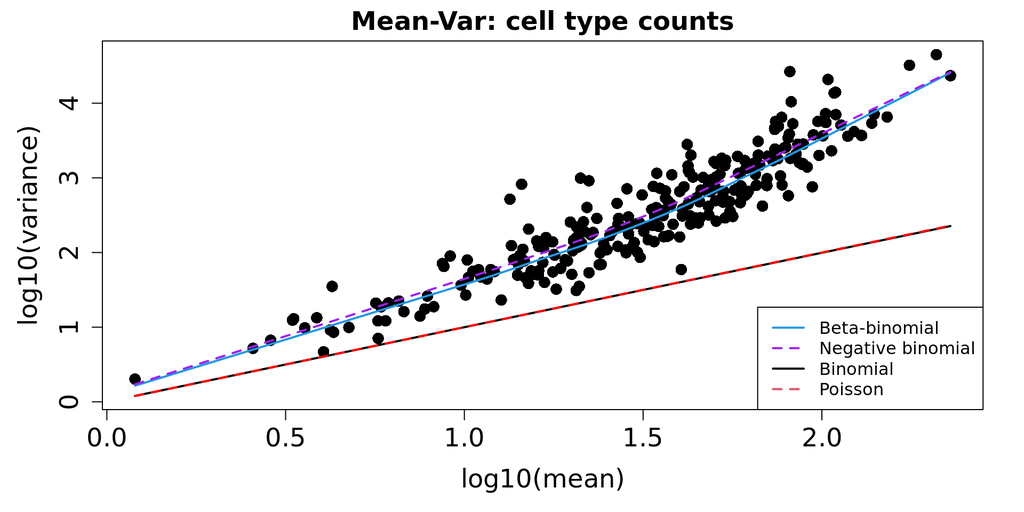

```r
par(mfrow=c(1,1))
MeanVar.logit.counts <- plotCellTypeMeanVar(props.logit$Counts)
```

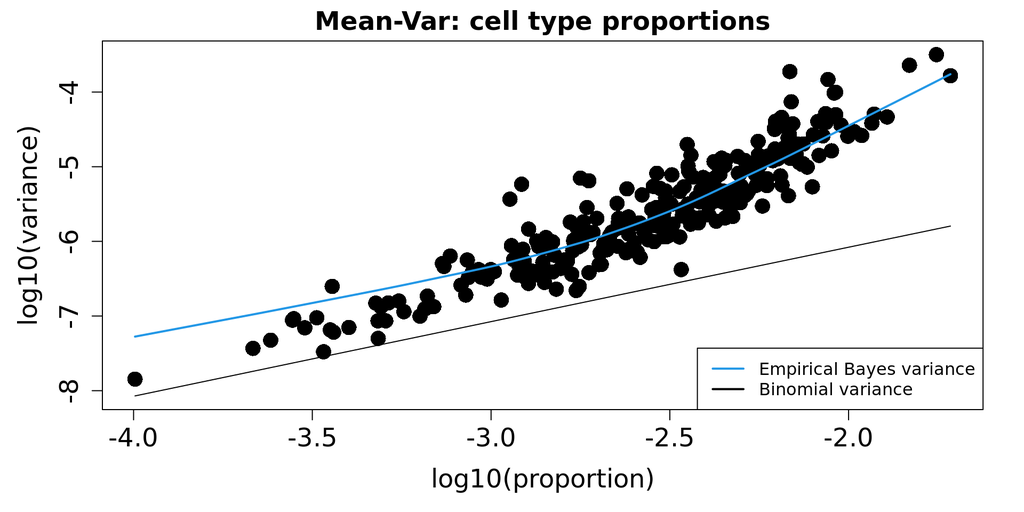

```r
MeanVar.logit.props <- plotCellTypePropsMeanVar(props.logit$Counts)
```

```r
MeanVar.logit.counts
```

```r
MeanVar.logit.props
```

```r
props.arcsin <- getTransformedProps(MB.combined$cluster, MB.combined$sample, transform="logit")
```

```
Performing logit transformation of proportions
```

```
Using classic mode.
```

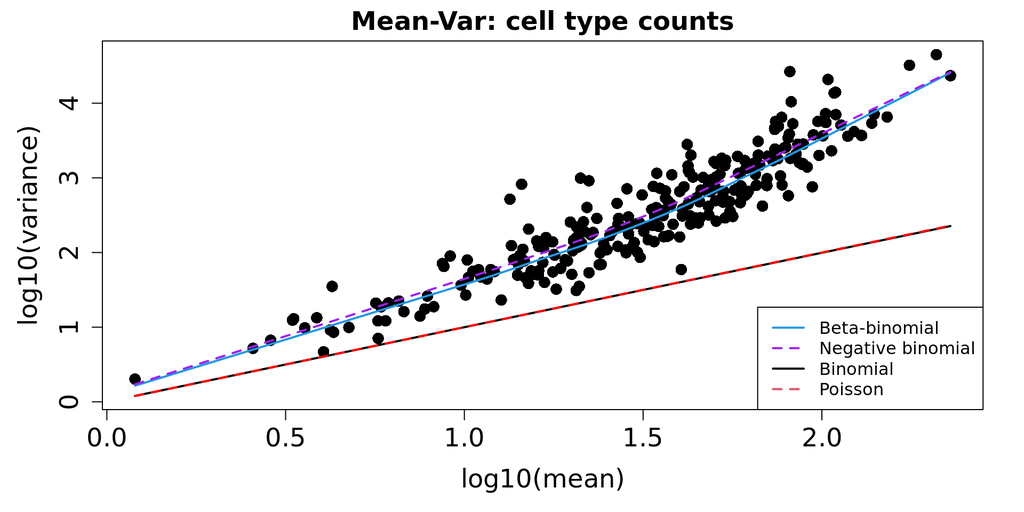

```r
par(mfrow=c(1,1))
plotCellTypeMeanVar(props.arcsin$Counts)
```

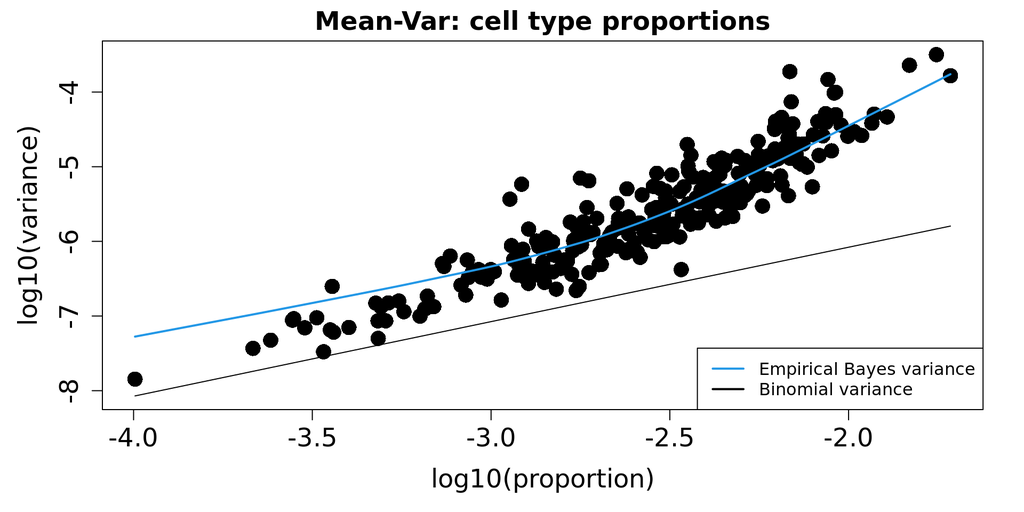

```r
plotCellTypePropsMeanVar(props.arcsin$Counts)
```

# Fitting linear models using the transformed proportions directly

If you are like me, you won’t feel very comfortable with a black-box approach where one function simply spits out a table of results. If you would like to have more control over your linear model and include extra covariates then you can fit a linear model in a more direct way using the transformed proportions that can be obtained by running the getTransformedProps function.

We have already obtained the proportions and transformed proportions when we ran the getTransformedProps function above. This function outputs a list object with three elements: Counts, TransformedProps and Proportions. These are all matrices with clusters/cell types in the rows and samples in the columns.

First we need to set up our sample information in much the same way we would if we were analysing bulk RNA-seq data. We can pretend that we have pairing information which corresponds to our original vs bootstrapped samples to make our model a little more complicated for demonstration purposes.

# set up sample info

```r
group <- c("t0_UF","t0_UF","t0_UF","t1_15HF","t1_15HF","t1_15HF","t2_30HF","t2_30HF","t3_60HF","t3_60HF","t3_60HF","t4_120HF","t4_120HF","t5_240HF","t5_240HF")
sampleMB <- c(1,2,3,1,2,3,1,2,1,2,3,1,2,1,2)
mb.df <- data.frame(group,sampleMB)
mb.df
```

| group | sampleMB |
| --- | --- |
| t0_UF | 1 |
| t0_UF | 2 |
| t0_UF | 3 |
| t1_15HF | 1 |
| t1_15HF | 2 |
| t1_15HF | 3 |
| t2_30HF | 1 |
| t2_30HF | 2 |
| t3_60HF | 1 |
| t3_60HF | 2 |

[output cut: 5 more lines]

# Design model matrix

We can set up a design matrix taking into account group and pairing information. Please note that the way that propeller has been designed is such that the group information is *always* first in the design matrix specification, and there is NO intercept. If you are new to design matrices and linear modelling, I would highly recommend reading the r BiocStyle::Biocpkg(“limma”) manual, which is incredibly extensive and covers a variety of different experimental set ups.

```r
design <- model.matrix(~ 0 + group + sampleMB, data = mb.df, na.action)
design
```

```
   groupt0_UF groupt1_15HF groupt2_30HF groupt3_60HF groupt4_120HF groupt5_240HF sampleMB
1           1            0            0            0             0             0        1
2           1            0            0            0             0             0        2
3           1            0            0            0             0             0        3
4           0            1            0            0             0             0        1
5           0            1            0            0             0             0        2
6           0            1            0            0             0             0        3
7           0            0            1            0             0             0        1
8           0            0            1            0             0             0        2
9           0            0            0            1             0             0        1
10          0            0            0            1             0             0        2
11          0            0            0            1             0             0        3
12          0            0            0            0             1             0        1
13          0            0            0            0             1             0        2
14          0            0            0            0             0             1        1
15          0            0            0            0             0             1        2
attr(,"assign")
[1] 1 1 1 1 1 1 2
attr(,"contrasts")
attr(,"contrasts")$group
[1] "contr.treatment"
```

#ANOVA

## ANOVA logit

```r
MB.anova.logit <- propeller.anova(prop.list=props.logit, design=design, coef = c(1,2,3,4,5,6),
                robust=TRUE, trend=FALSE, sort=TRUE)
MB.anova.logit
```

|  | PropMean.groupt0_UF | PropMean.groupt1_15HF | PropMean.groupt2_30HF | PropMean.groupt3_60HF | PropMean.groupt4_120HF | PropMean.groupt5_240HF | Fstatistic | P.Value | FDR |
| --- | --- | --- | --- | --- | --- | --- | --- | --- | --- |
| EnteroAnte_195 | 0.0001658854 | 1.284245e-03 | 9.205717e-04 | 3.296309e-03 | 5.856971e-03 | 1.810529e-04 | 9.67064657 | 0.0003943282 | 0.1068630 |
| VascularHR_66 | 0.0062049675 | 6.178715e-03 | 8.607427e-03 | 2.925781e-03 | 9.733221e-04 | 4.775549e-03 | 6.10728585 | 0.0031743232 | 0.3412815 |
| FastMuscle_122 | 0.0060518150 | 1.541851e-03 | 5.313038e-03 | 1.474378e-03 | 2.289023e-04 | 2.667505e-03 | 5.99044533 | 0.0037780240 | 0.3412815 |
| Hepatocyte_189 | 0.0014266369 | 2.936716e-03 | 9.872205e-04 | 6.979352e-04 | 3.481654e-03 | 9.475022e-04 | 4.90425027 | 0.0080982363 | 0.4720345 |
| NucErythro_109 | 0.0017947511 | 9.910424e-03 | 2.410963e-03 | 3.144889e-03 | 6.241973e-04 | 1.864870e-03 | 4.86582514 | 0.0087091242 | 0.4720345 |
| Hepatocyte_134 | 0.0023522357 | 6.593560e-03 | 2.465037e-03 | 2.189816e-03 | 4.677482e-04 | 1.689004e-03 | 4.41899566 | 0.0129859409 | 0.5118338 |
| VasSmooMus_182 | 0.0021395512 | 3.236320e-03 | 1.817638e-03 | 8.772765e-04 | 2.519874e-04 | 1.044945e-03 | 4.29833931 | 0.0136084984 | 0.5118338 |
| HorizRetIn_221 | 0.0010684035 | 7.331762e-04 | 1.056062e-03 | 8.799557e-04 | 4.018657e-03 | 4.543614e-04 | 4.13552915 | 0.0157407285 | 0.5118338 |
| IntSecProg_229 | 0.0013602019 | 2.276119e-03 | 8.418959e-04 | 4.618651e-04 | 5.895697e-04 | 1.225998e-03 | 4.01786543 | 0.0175163958 | 0.5118338 |
| SkFaMuCeCr_244 | 0.0010272679 | 2.184019e-04 | 9.473345e-04 | 4.886969e-04 | 2.042183e-04 | 1.728648e-03 | 3.80181485 | 0.0213958756 | 0.5118338 |

[output cut: 261 more lines]

## ANOVA logit with FDR >0.05 filtered out

```r
MB.anova.logit %>% filter(FDR <= 0.05)
```

| PropMean.groupt0_UF | PropMean.groupt1_15HF | PropMean.groupt2_30HF | PropMean.groupt3_60HF | PropMean.groupt4_120HF | PropMean.groupt5_240HF | Fstatistic | P.Value | FDR |
| --- | --- | --- | --- | --- | --- | --- | --- | --- |

```r
MB.anova.arcsin <- propeller.anova(prop.list=props.arcsin, design=design, coef = c(1,2,3,4,5,6),
                robust=TRUE, trend=FALSE, sort=TRUE)
MB.anova.arcsin
```

|  | PropMean.groupt0_UF | PropMean.groupt1_15HF | PropMean.groupt2_30HF | PropMean.groupt3_60HF | PropMean.groupt4_120HF | PropMean.groupt5_240HF | Fstatistic | P.Value | FDR |
| --- | --- | --- | --- | --- | --- | --- | --- | --- | --- |
| EnteroAnte_195 | 0.0001658854 | 1.284245e-03 | 9.205717e-04 | 3.296309e-03 | 5.856971e-03 | 1.810529e-04 | 9.67064657 | 0.0003943282 | 0.1068630 |
| VascularHR_66 | 0.0062049675 | 6.178715e-03 | 8.607427e-03 | 2.925781e-03 | 9.733221e-04 | 4.775549e-03 | 6.10728585 | 0.0031743232 | 0.3412815 |
| FastMuscle_122 | 0.0060518150 | 1.541851e-03 | 5.313038e-03 | 1.474378e-03 | 2.289023e-04 | 2.667505e-03 | 5.99044533 | 0.0037780240 | 0.3412815 |
| Hepatocyte_189 | 0.0014266369 | 2.936716e-03 | 9.872205e-04 | 6.979352e-04 | 3.481654e-03 | 9.475022e-04 | 4.90425027 | 0.0080982363 | 0.4720345 |
| NucErythro_109 | 0.0017947511 | 9.910424e-03 | 2.410963e-03 | 3.144889e-03 | 6.241973e-04 | 1.864870e-03 | 4.86582514 | 0.0087091242 | 0.4720345 |
| Hepatocyte_134 | 0.0023522357 | 6.593560e-03 | 2.465037e-03 | 2.189816e-03 | 4.677482e-04 | 1.689004e-03 | 4.41899566 | 0.0129859409 | 0.5118338 |
| VasSmooMus_182 | 0.0021395512 | 3.236320e-03 | 1.817638e-03 | 8.772765e-04 | 2.519874e-04 | 1.044945e-03 | 4.29833931 | 0.0136084984 | 0.5118338 |
| HorizRetIn_221 | 0.0010684035 | 7.331762e-04 | 1.056062e-03 | 8.799557e-04 | 4.018657e-03 | 4.543614e-04 | 4.13552915 | 0.0157407285 | 0.5118338 |
| IntSecProg_229 | 0.0013602019 | 2.276119e-03 | 8.418959e-04 | 4.618651e-04 | 5.895697e-04 | 1.225998e-03 | 4.01786543 | 0.0175163958 | 0.5118338 |
| SkFaMuCeCr_244 | 0.0010272679 | 2.184019e-04 | 9.473345e-04 | 4.886969e-04 | 2.042183e-04 | 1.728648e-03 | 3.80181485 | 0.0213958756 | 0.5118338 |

[output cut: 261 more lines]

```r
MB.anova.arcsin %>% filter(FDR <= 0.05)
```

| PropMean.groupt0_UF | PropMean.groupt1_15HF | PropMean.groupt2_30HF | PropMean.groupt3_60HF | PropMean.groupt4_120HF | PropMean.groupt5_240HF | Fstatistic | P.Value | FDR |
| --- | --- | --- | --- | --- | --- | --- | --- | --- |

# UMAP

https://www.evanpickett.com/blog/2016/10/19/r-ggsave-tiff-files-are-too-big ggsave(“Fig 4a.tiff”, plot = p4, width=600, height=450, units=“mm”, dpi=300, compression = “lzw”)

# New short cell type UMAP

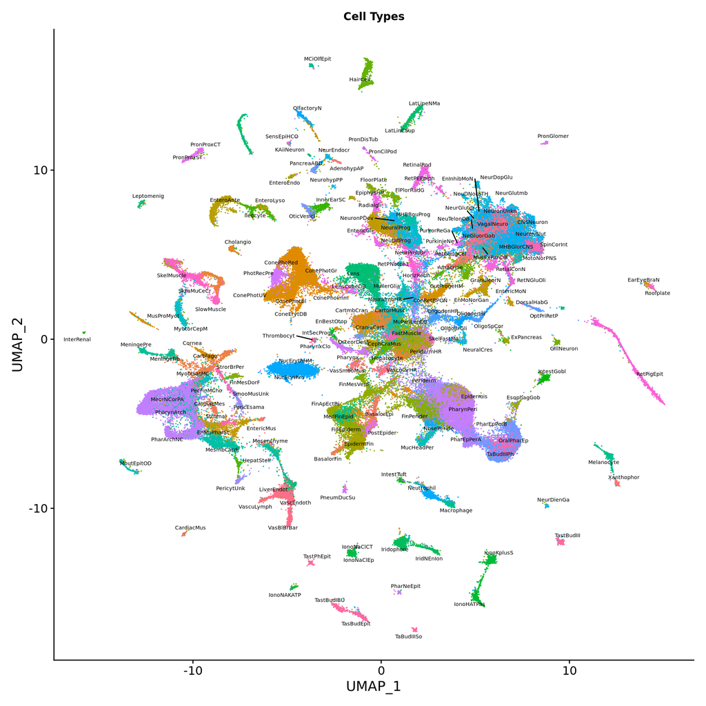

```r
plot <- DimPlot(MB.combined, reduction = "umap", group.by = "short_cell_type", label=TRUE, label.size = 1.9, repel = TRUE, raster=FALSE) + theme(legend.position = "none") +
  labs(title = "Cell Types", size = 12) +
  theme(plot.title = element_text(size=11))
plot
```

```r
plot2 <- DimPlot(MB.combined, reduction = "umap", group.by = "short_cell_type", label=TRUE, label.size = 1.9, repel = TRUE) + theme(legend.position = "none") +
  labs(title = "Cell Types", size = 12) +
  theme(plot.title = element_text(size=11))
```

```
Rasterizing points since number of points exceeds 100,000.
To disable this behavior set `raster=FALSE`
```

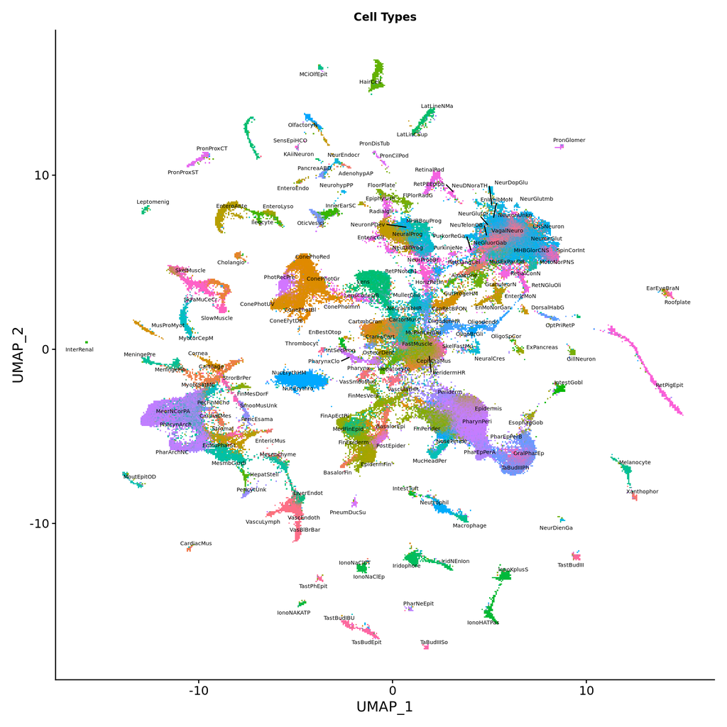

```r
plot2
```

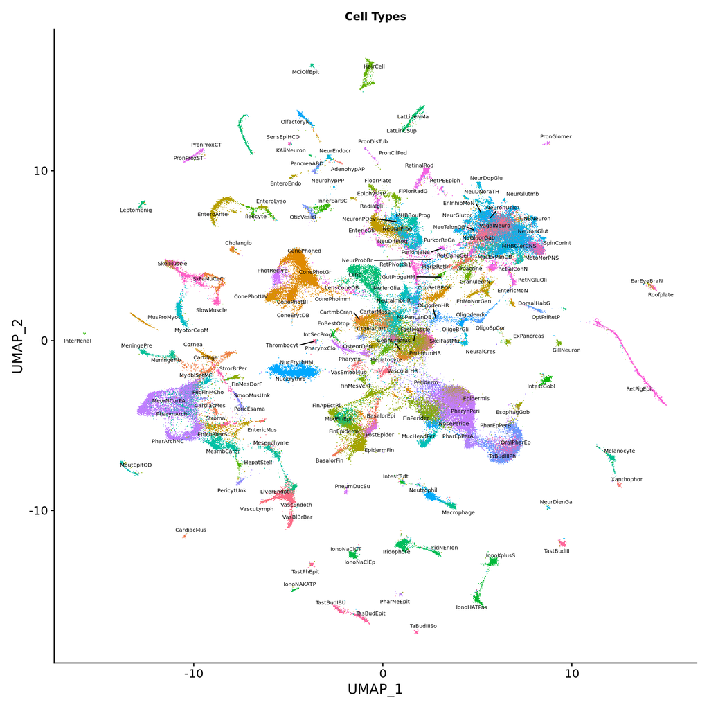

```r
plot3 <- DimPlot(MB.combined, reduction = "umap", group.by = "short_cell_type", label=TRUE, label.size = 1.9, repel = TRUE,raster = TRUE, raster.dpi = c(1000, 1000)) + theme(legend.position = "none") +
  labs(title = "Cell Types", size = 12) +
  theme(plot.title = element_text(size=11))
plot3
```

# save plot

ggsave(“Fig2_.tiff”, plot = plot, width=60, height=60, units=“mm”, dpi=300, compression = “lzw”)

https://www.datanovia.com/en/blog/how-to-save-a-ggplot/

Open a graphic device using one of the following functions: pdf(“r-graphics.pdf”), svg(“r-graphics.svg”), png(“r-graphics.png”), tiff(“r-graphics.tiff”), jpeg(“r-graphics.jpg”), and so on. Additional arguments indicating the width and the height (in inches) of the graphics region can be also specified in the mentioned function.

Create and print a plot Close the graphic device using the function dev.off()

```r
#save_plot("250210_atlas_short_celltype_v1_4_10x10.svg", plot, base_width=10, base_height=10)
```

```r
#save_plot("250210_atlas_short_celltype_v1_4_10x10_raster.svg", plot2, base_width=10, base_height=10)
```

```r
#save_plot("250210_atlas_short_celltype_v1_4_10x10_raster1000.svg", plot3, base_width=10, base_height=10)
```

```r
#save_plot("250210_atlas_short_celltype_v1_4_10x10.pdf", plot, base_width=10, base_height=10)
```

save_plot(“250127_DE_overall_genes_diff_reg_per_cluster_DESeq_v1_4_sqrt_scale.svg”, p6_overall, base_height = 10, base_width = 10)

```r
#save_plot("250210_atlas_short_celltype_v1_4_40x40cm_300dpi.svg", plot = plot, base_width=40, base_height=40, units="cm", dpi=300)
```

```r
#save_plot("250210_atlas_short_celltype_v1_4_40x40cm_600dpi.svg", plot = plot, base_width=40, base_height=40, units="cm", dpi=600)
```

```r
#save_plot("250210_atlas_short_celltype_v1_4_50x50cm_600dpi.svg", plot = plot, base_width=50, base_height=50, units="cm", dpi=600)
```

```r
#save_plot("250210_atlas_short_celltype_v1_4_60x60cm_600dpi.svg", plot = plot, base_width=60, base_height=60, units="cm", dpi=600)
```

# UMAPs Highlighted by condition

## UF

```r
Idents(MB.combined) <- "condition"
t0_UF.cells <-subset(MB.combined, idents = "t0_UF")
```

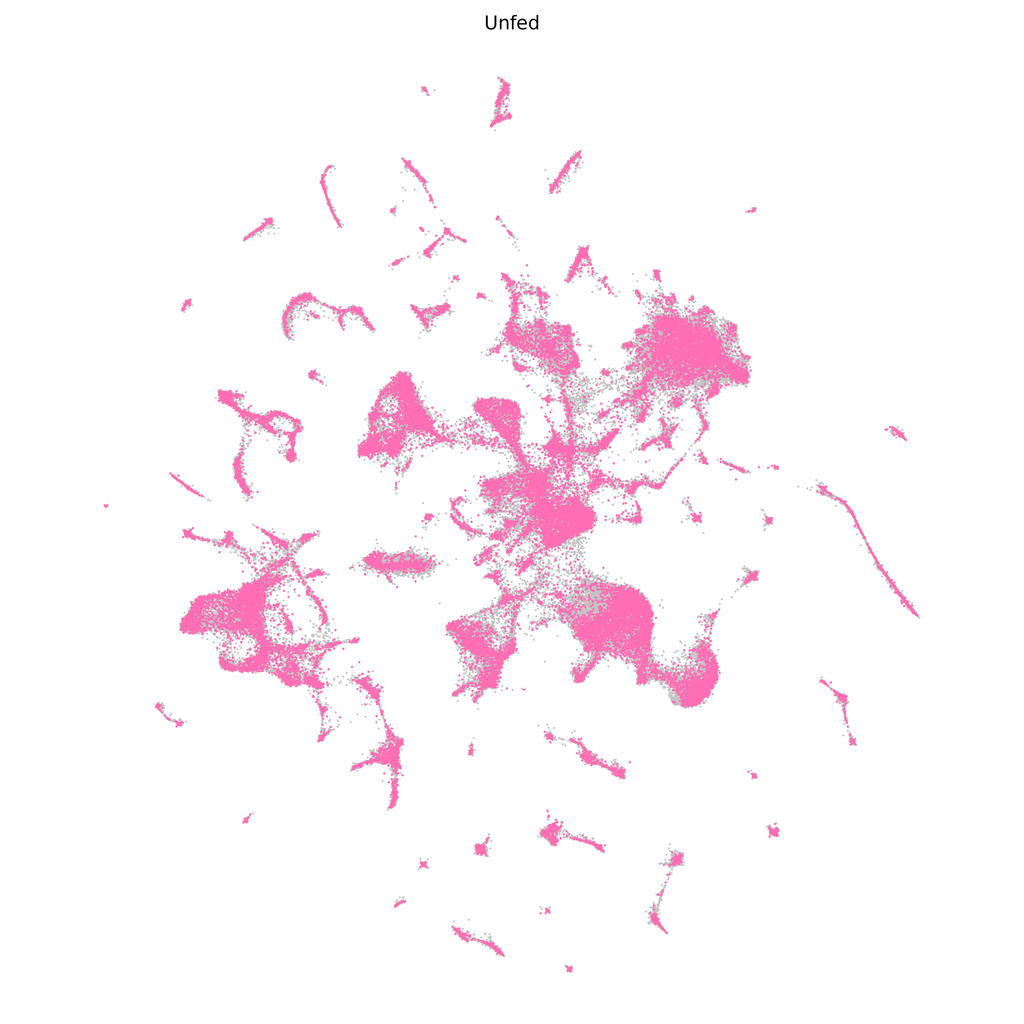

```r
t0_UF.UMAP <- DimPlot(MB.combined,
                      na.value = "grey10",
                      reduction = "umap",
                      label=FALSE,
                      raster=FALSE,
                      cells.highlight = colnames(t0_UF.cells),
                      cols.highlight = "hotpink1",
                      sizes.highlight = 0.1) +
  theme_void() +
  coord_fixed(1) +
  theme(plot.title = element_text(hjust = 0.5)) +
  theme(legend.position = "none") +
  ggtitle("Unfed")
t0_UF.UMAP
```

```r
#rm(t0_UF.cells)
#gc()
```

“t0_UF” “t1_15HF” “t2_30HF” “t3_60HF” “t4_120HF” “”

## 15 min

```r
t1_15HF.cells <-subset(MB.combined, idents = "t1_15HF")
```

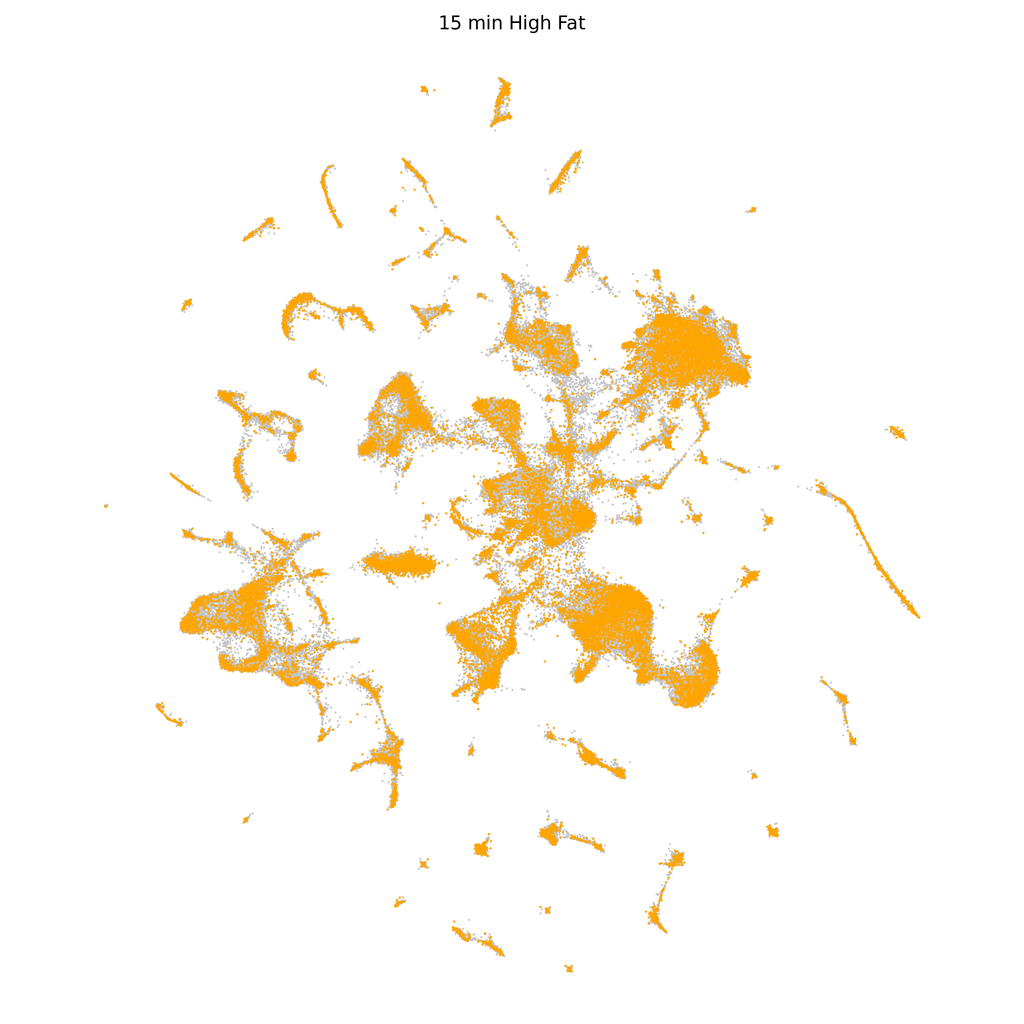

```r
t1_15HF.UMAP <- DimPlot(MB.combined,
                        na.value = "grey10",
                        reduction = "umap",
                        label=FALSE,
                        raster=FALSE,
                        cells.highlight = colnames(t1_15HF.cells),
                        cols.highlight = "orange",
                        sizes.highlight = 0.1) +
  theme_void() +
  coord_fixed(1) +
  theme(plot.title = element_text(hjust = 0.5)) +
  theme(legend.position = "none") +
  ggtitle("15 min High Fat")
t1_15HF.UMAP
```

```r
#rm(t1_15HF.cells)
#gc()
```

## 30 min

```r
t2_30HF.cells <-subset(MB.combined, idents = "t2_30HF")
```

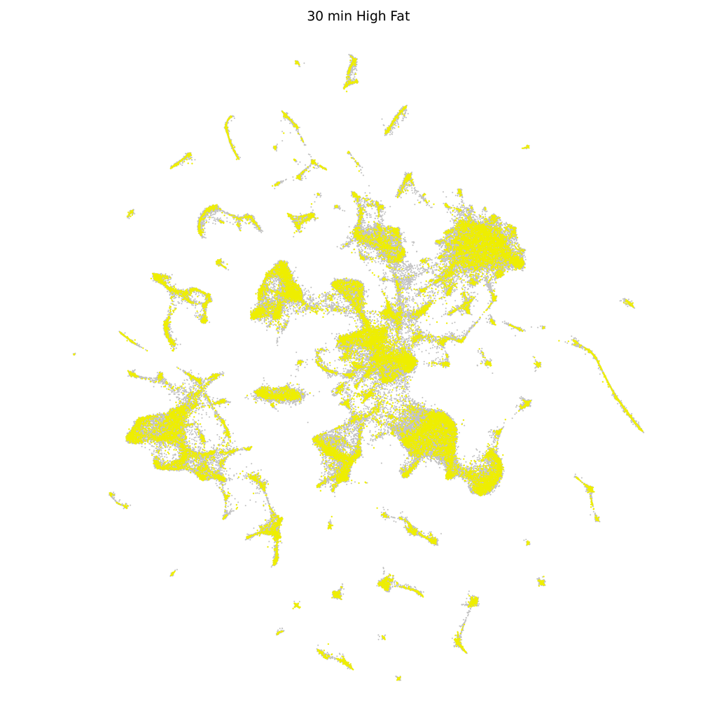

```r
t2_30HF.UMAP <- DimPlot(MB.combined,
                        na.value = "grey10",
                        reduction = "umap",
                        label=FALSE,
                        raster=FALSE,
                        cells.highlight = colnames(t2_30HF.cells),
                        cols.highlight = "yellow2",
                        sizes.highlight = 0.1) +
  theme_void() +
  coord_fixed(1) +
  theme(plot.title = element_text(hjust = 0.5)) +
  theme(legend.position = "none") +
  ggtitle("30 min High Fat")
t2_30HF.UMAP
```

```r
#rm(t2_30HF.cells)
#gc()
```

## 60 min

```r
t3_60HF.cells <-subset(MB.combined, idents = "t3_60HF")
```

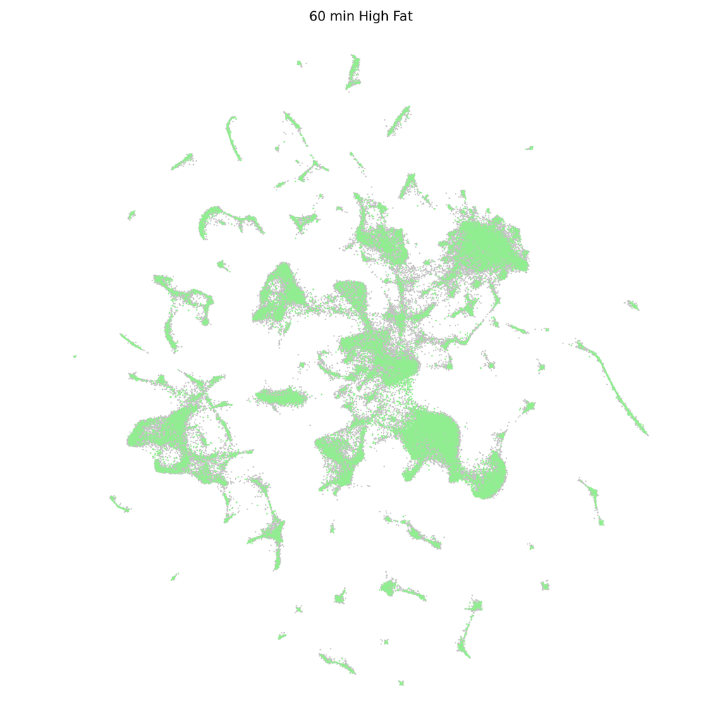

```r
t3_60HF.UMAP <- DimPlot(MB.combined,
                        na.value = "grey10",
                        reduction = "umap",
                        label=FALSE,  raster=FALSE,
                        cells.highlight = colnames(t3_60HF.cells),
                        cols.highlight = "lightgreen",
                        sizes.highlight = 0.1) +
  theme_void() +
  coord_fixed(1) +
  theme(plot.title = element_text(hjust = 0.5)) +
  theme(legend.position = "none") +
  ggtitle("60 min High Fat")
t3_60HF.UMAP
```

```r
#rm(t3_60HF.cells)
#gc()
```

## 2 hr

```r
t4_120HF.cells <-subset(MB.combined, idents = "t4_120HF")
```

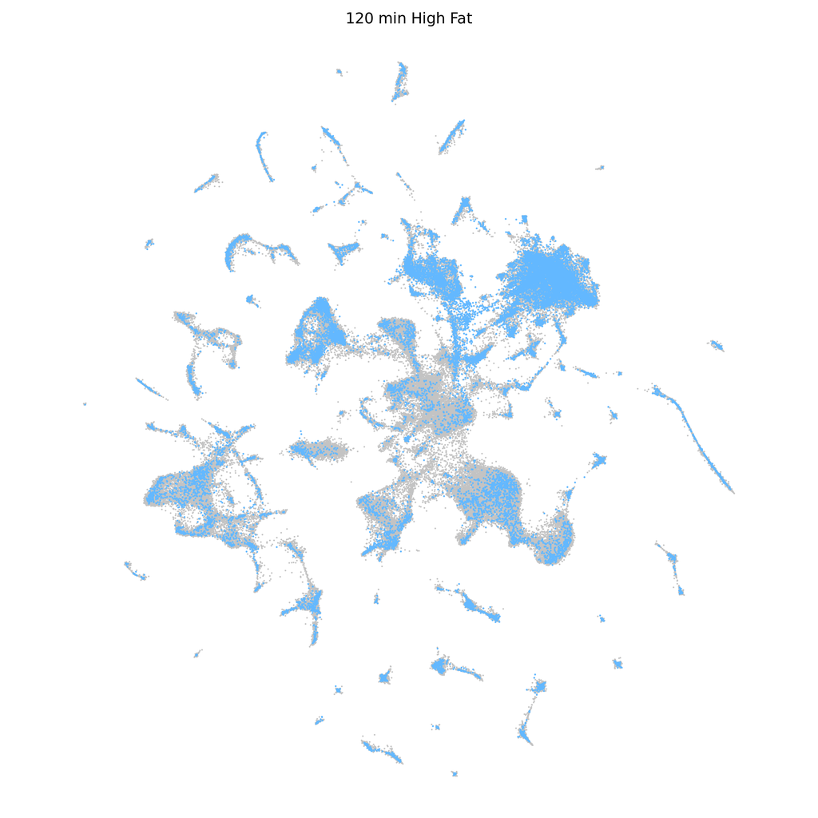

```r
t4_120HF.UMAP <- DimPlot(MB.combined,
                         na.value = "grey10",
                         reduction = "umap",
                         label=FALSE,
                         raster=FALSE,
                         cells.highlight = colnames(t4_120HF.cells),
                         cols.highlight = "steelblue1",
                         sizes.highlight = 0.1) +
  theme_void() +
  coord_fixed(1) +
  theme(plot.title = element_text(hjust = 0.5)) +
  theme(legend.position = "none") +
  ggtitle("120 min High Fat")
t4_120HF.UMAP
```

```r
#rm(t4_120HF.cells)
#gc()
```

## 4 hr

```r
t5_240HF.cells <-subset(MB.combined, idents = "t5_240HF")
```

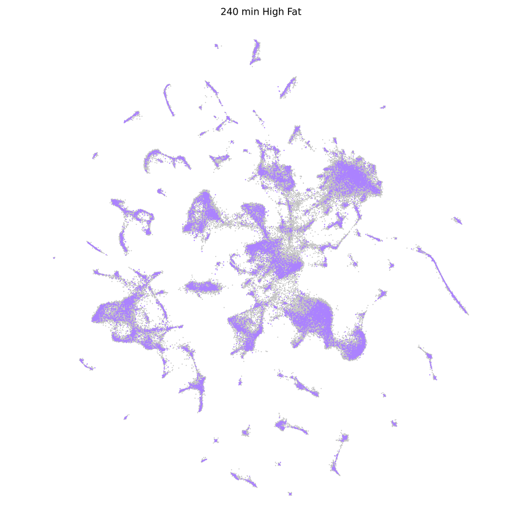

```r
t5_240HF.UMAP <- DimPlot(MB.combined,
                         na.value = "grey10",
                         reduction = "umap",
                         label=FALSE,
                         raster=FALSE,
                         cells.highlight = colnames(t5_240HF.cells),
                         cols.highlight = "mediumpurple1",
                         sizes.highlight = 0.1) +
  theme_void() +
  coord_fixed(1) +
  theme(plot.title = element_text(hjust = 0.5)) +
  theme(legend.position = "none") +
  ggtitle("240 min High Fat")
t5_240HF.UMAP
```

```r
#rm(t5_240HF.cells)
#gc()
```

# combined plot

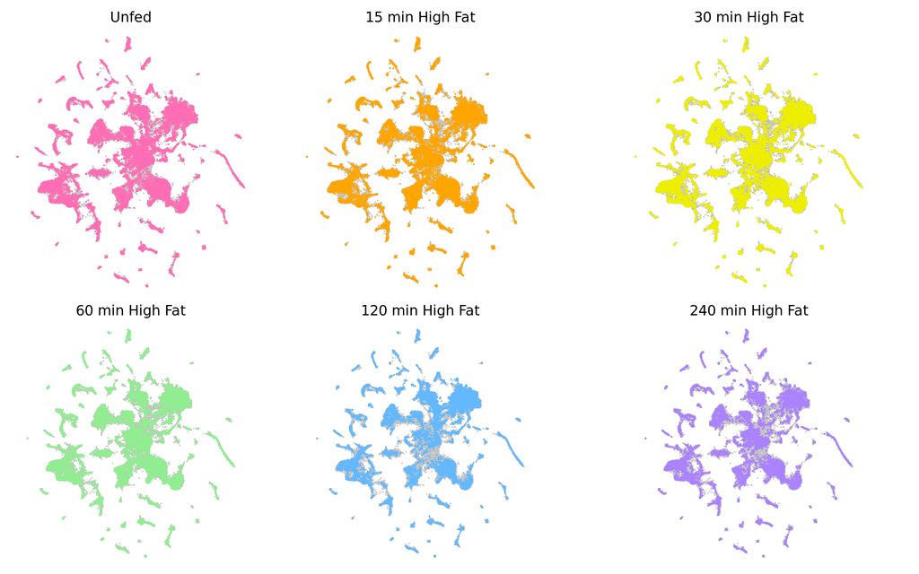

```r
combined_plot <- t0_UF.UMAP+t1_15HF.UMAP+t2_30HF.UMAP+t3_60HF.UMAP+t4_120HF.UMAP+t5_240HF.UMAP
combined_plot
```

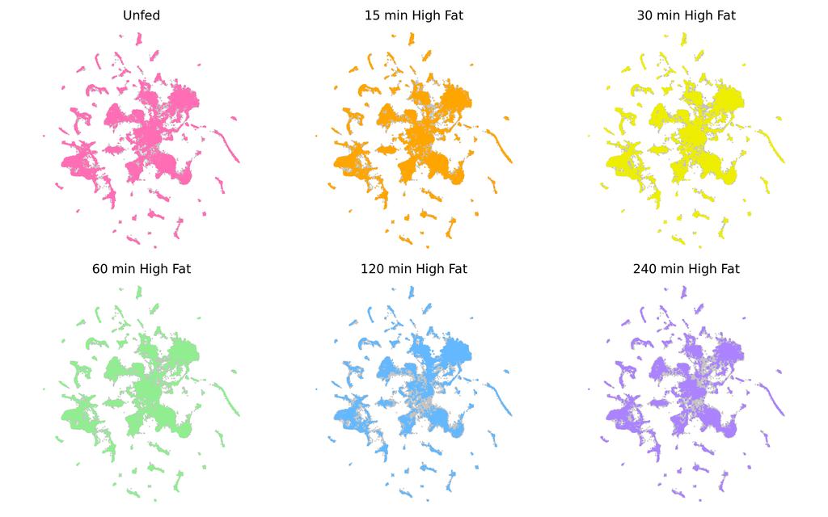

```r
combined_plot2 <-(t0_UF.UMAP | t1_15HF.UMAP | t2_30HF.UMAP) / (t3_60HF.UMAP | t4_120HF.UMAP | t5_240HF.UMAP) + plot_layout(guides = 'collect')
combined_plot2
```

# save combined plot

```r
save_plot("250210_highlight_by_condition_combined.svg", combined_plot, base_height = 7.5, base_width = 12)
save_plot("250210_highlight_by_condition_combined.png", combined_plot, base_height = 7.5, base_width = 12)
```

```r
save_plot("250210_highlight_by_condition_combined.tif", combined_plot, base_height = 7.5, base_width = 12)
```